# Distrito Capital

Beatriz Valdez

30 de septiembre de 2016

# Poblacion. Caracteristicas

Subo los paquetes necesarios para subir la data, en este caso especificamente hojas de calculos. Necesito, entonces, el paquete **readxl**

```r
require(readr)
require(readxl)
```

```r
# evolucion de la poblacion distrito capital
# salto las primeras ocho lineas con 'skip'
evolucion<- read_excel("d:/clasesInsumos/clases2016I/dtoCapital/Poblacion3.xls",
                         skip = 9)
```

[output not shown]

```r
evolucionIntercensal<- read_excel("d:/clasesInsumos/clases2016I/dtoCapital/Poblacion1.xls",
                                  skip = 11
                                  )
```

[output not shown]

Exploro que tengo en el marco de datos

```r
head(evolucion)
```

```
## # A tibble: 6 × 6
##            ``      ``     ``         ``         ``        ``
##         <chr>   <dbl>  <dbl>      <dbl>      <dbl>     <dbl>
## 1 1961.000000 1116245     NA         NA         NA        NA
## 2 1971.000000 1658500 542255 48.5784931 3.77579394 15.468886
## 3 1981.000000 1816901 158401  9.5508592 0.91950261 12.515907
## 4 1990.000000 1823222   6321  0.3479001 0.03858418 10.070120
## 5 2001.000000 1836286  13064  0.7165337 0.07933829  7.965079
## 6     2011 a/ 1943901 107615  5.8604705 0.60000000  7.139364
```

```r
head(evolucionIntercensal)
```

```
## # A tibble: 6 × 5
##      ``     ``     ``     ``     ``
##   <chr>  <dbl>  <dbl>  <dbl>  <dbl>
## 1   0-4 215741 190372 154815 146125
## 2   5-9 193780 175256 166070 134852
## 3 10-14 186217 176826 163111 141155
## 4 15-19 196200 185337 165884 158247
## 5 20-24 202468 197125 180244 179042
## 6 25-29 186442 177941 158468 171095
```

Me doy cuenta de que debo limpiar la data antes de iniciar las exploraciones:

- eliminar filas no deseadas (las que estan despues de la fila 6)
- darles, nuevamente, nombre a las variables
- verificar el tipo de variable que tengo en el marco de datos
- eliminar simbolos o caracteres en las categorias que podrian impedir un despliegue correcto del tipo de variables

Todo ese procedimiento es parte de lo que se conoce como **pre-procesar la data**

## Pre-procesamiento de la data

Quito las filas que no necesito para mi analisis

```r
#  elimino filas no deseadas, filas 7 en adelante
evolucion<- evolucion[1:6,]
```

Renombro las columnas, estos es, las variables

```r
# coloco nombres  de las variables
names(evolucion)<-c("censo", "pob.total",
                    "variacion", "porVar",
                    "cre.geom", "porcentaje_deltotal")
```

Verifico que tipo de variables tiene el marco de datos. En R las variables que nos interesan para el anÃ¡lisis que estamos haciendo pueden ser de tipo:

- numericas (numeric) lo que conocemos comunmente como variables continuas
- enteros (intger), lo que denominamos comunmente variables discretas
- factor, generalmente variables ordinales
- carecter (character), corresponde a cadena de textos. Generalmente este es el tipo de variables que deseamos para variables nominales
- fecha (date)

```r
# verifico tipo de variables
sapply(evolucion, class)
```

```
##               censo           pob.total           variacion
##         "character"           "numeric"           "numeric"
##              porVar            cre.geom porcentaje_deltotal
##           "numeric"           "numeric"           "numeric"
```

Algunas variables que se nos ofrecen entre comillas suelen interpretarse como de tipo caracter. Eso se debe a que el el contenido de alguna de las filas hay algun simboloque no es coherente con el resto de los datos. En esos casos R lleva toda la columna a caracter. Para hacer esta limpieza, es necesario eliminar el simbolo que esta causando el problema

```r
# elimino a/
evolucion$censo<-gsub("a/", "", evolucion$censo)
evolucion$censo
```

```
## [1] "1961.000000" "1971.000000" "1981.000000" "1990.000000" "2001.000000"
## [6] "2011 "
```

Todavia queda algun espacio en la categoria anterior. Si lo dejo, R continuara mostrando el contenido de la variable como de tipo caracter. Para eliminar este espacio hare uso del paquete **stringr**

```r
# cargo el paquete stringr
require(stringr)
# elimino el espacio adicional
str_trim(evolucion$censo)
```

```
## [1] "1961.000000" "1971.000000" "1981.000000" "1990.000000" "2001.000000"
## [6] "2011"
```

```r
# verifico de nuevo el tipo de de variable
sapply(evolucion, class)
```

```
##               censo           pob.total           variacion
##         "character"           "numeric"           "numeric"
##              porVar            cre.geom porcentaje_deltotal
##           "numeric"           "numeric"           "numeric"
```

```r
#convierto en numerica
evolucion$censo<-as.numeric(evolucion$censo)
```

Limpio ahora el segundo marco de datos. Aqui voy a crear, a partir del marco de datos que subi, otros en los que separo la evolucion de los grupos de edades totales, y luego segun sexo

```r
# creo el marco de datos con la informacion de los grupos de edades y poblaciontotal
evolucion_total <- evolucionIntercensal[1:16,]

# les doy nombre a las variables
names(evolucion_total)<-c("grupos", "1981", "1990", "2001", "2011")

evolucion_hombres <- evolucionIntercensal[20:35,]
names(evolucion_hombres)<-c("grupos", "1981", "1990", "2001", "2011")
evolucion_hombres$concepto <-rep("hombre", 16)

# creos los marcos de nombres para los grupos de edades segun sexo
evolucion_mujeres <- evolucionIntercensal[39:54,]
names(evolucion_mujeres)[1:5]<-c("grupos", "1981", "1990", "2001", "2011")
evolucion_mujeres$concepto <-rep("mujer", 16)
```

Voy a unir los dos marcos relacionados con los grupos de edad segun sexo para facilitar el calculo de la tasa de variacion

```r
#uno los marcos de datos segun sexo
evolucionSexos <-rbind(evolucion_hombres, evolucion_mujeres)
```

## Crear indicadores

Ahora tengo la data como la deseo para hacer los diferentes analisis. Ahora debo crear indicadores que me faciliten el analisis e interpretacion de la data, asi como el formularme algunas preguntas de cara al analisis prospectivo Por el tipo de datos que tengo, observo que el indicador mas apropiado es la tasa de variacion. Las creo.

```r
# calculo tasas de variacion


#1990-1981
evolucionSexos$var9081<-round((evolucionSexos[,3]-evolucionSexos[,2])/evolucionSexos[,2]*100 ,2)

# 2001-1990
evolucionSexos$var0190<-round((evolucionSexos[,4]-evolucionSexos[,3])/evolucionSexos[,2]*100 ,2)

# 211-2001
evolucionSexos$var1101<-round((evolucionSexos[,5]-evolucionSexos[,4])/evolucionSexos[,4]*100 ,2)

# 2011-1981
evolucionSexos$var11_81<-round((evolucionSexos[,5]-evolucionSexos[,2])/evolucionSexos[,2]*100 ,2)


# Poblacion total 2011-1981
evolucion_total$var11_81<-round((evolucion_total[,5]-evolucion_total[,2])/evolucion_total[,2]*100 ,2)
```

Despues de hacer las tasas, procedo, entonces, a explorar la data.

## Analisis exploratorio

La pregunta inicial que me surge, y dado que las tasas de variacion me muestran como ha evolucionado una variable dada en un lapso determinado, me pregunto como se ha comportado la poblacion del Distrito Capital, total y, luego segun grupos de edades entre los censos del 90, 2001, y 2011. En particular me pregunto si ha habido crecimientos o decrecimientos importantes en alguno de esos grupo

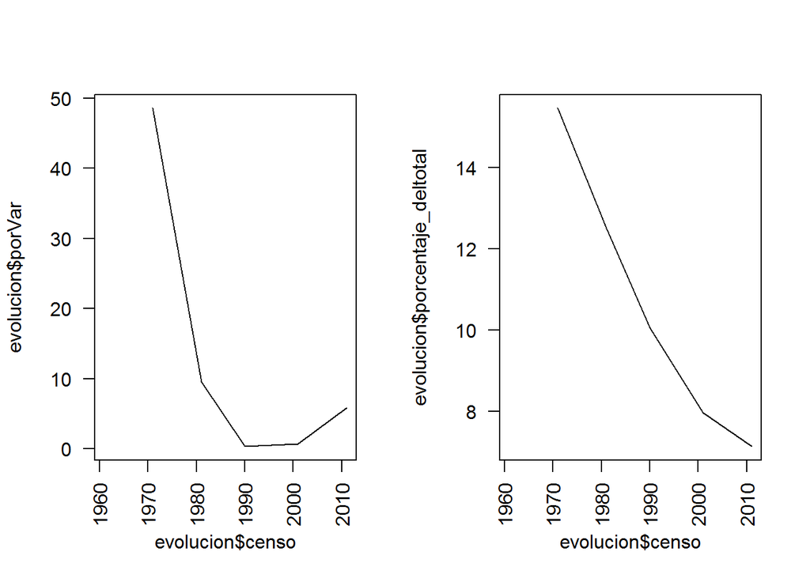

```r
par(mfrow=c(1, 2))
plot(evolucion$porVar~ evolucion$censo, type="l",
    las=2)
plot(evolucion$porcentaje_deltotal~ evolucion$censo,
   type="l", las=2)
```

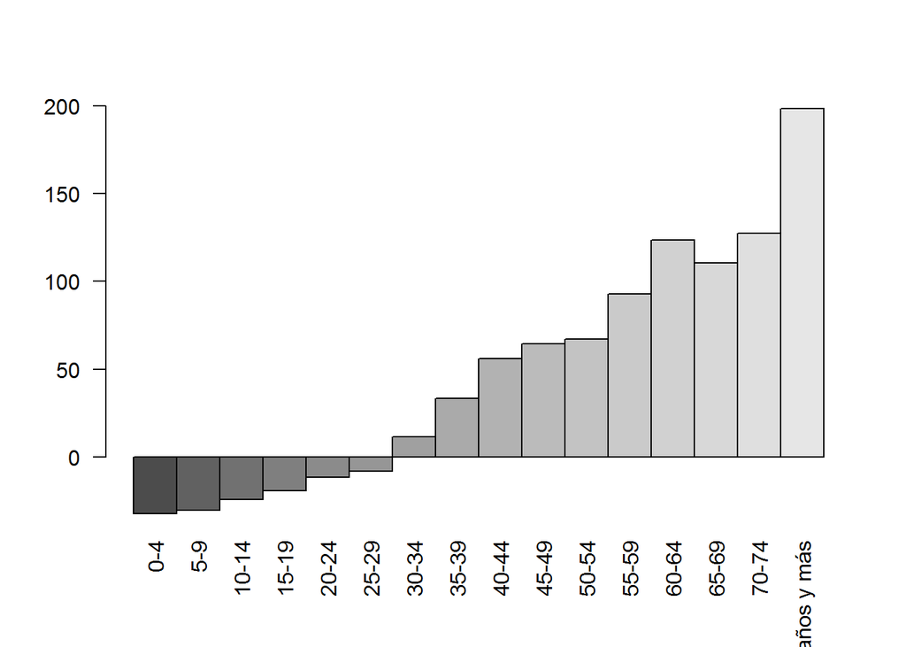

```r
barplot(as.matrix(evolucion_total$var11_81),
        beside = T, names.arg = evolucion_total$grupos,
        las=2, ylim=c(-33,200))
```

Se nota que ha habido un decrecimiento en los grupos de edades menores a 15 años, pero se han incrementado los grupos de edades mayores a 50 años en el lapso analizado. Quiero observar este comportamiento de acuerdo con el sexo.

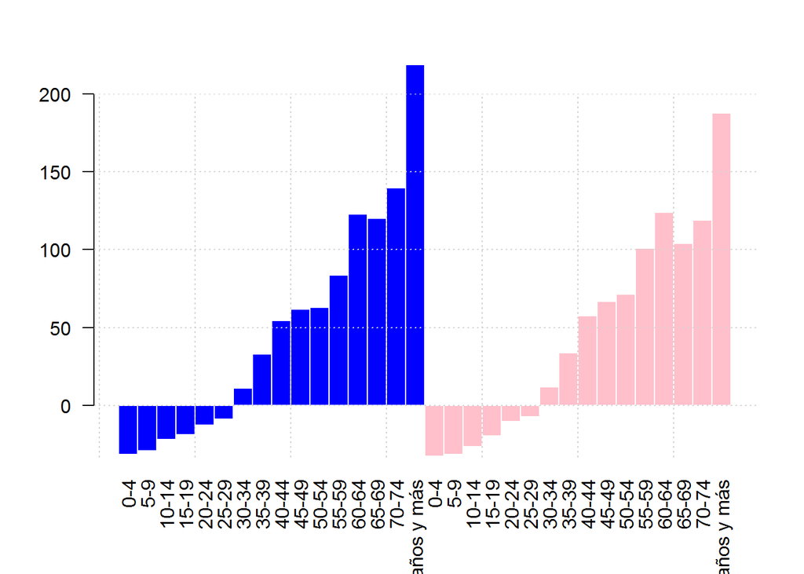

```r
# creo el vector de colores
evolucionSexos$colores<-ifelse(
        evolucionSexos$concepto == "hombre","blue","pink")


barplot(as.matrix(evolucionSexos$var11_81),
    beside = T, names.arg = evolucionSexos$grupos,
    las=2, ylim=c(-33,200),
    col=evolucionSexos$colores,
    border="white")
grid()
```

```r
Variaciones <-as.data.frame(evolucionSexos[,c(1,6:10)])

# inspecciono el valor minimo y maximo de cada lapso para ajustar el eje y de los graficos de barrar que hare luego
range(Variaciones[,3])
```

```
## [1] -11.94  39.95
```

```r
range(Variaciones[,4])
```

```
## [1] -16.72  86.38
```

```r
range(Variaciones[,5])
```

```
## [1] -19.82  56.03
```

Creo los graficos de barra

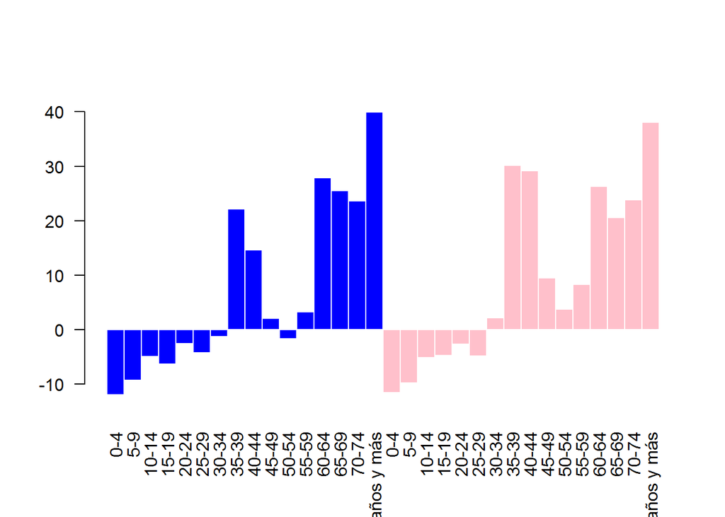

```r
# variacion en 1990 respecto a 1981
barplot(as.matrix(Variaciones[,3]),
    beside = TRUE, names.arg = Variaciones[,1],
    las=2, ylim=c(-15,45),
    col=evolucionSexos$colores,
    border="white")
```

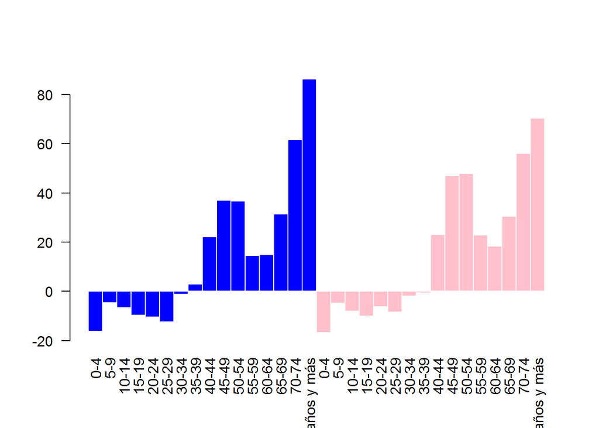

```r
# variacion en 2001 respecto a 1990
barplot(as.matrix(Variaciones[,4]),
    beside = TRUE, names.arg = Variaciones[,1],
    las=2, ylim=c(-20,90),
    col=evolucionSexos$colores,
    border="white")
```

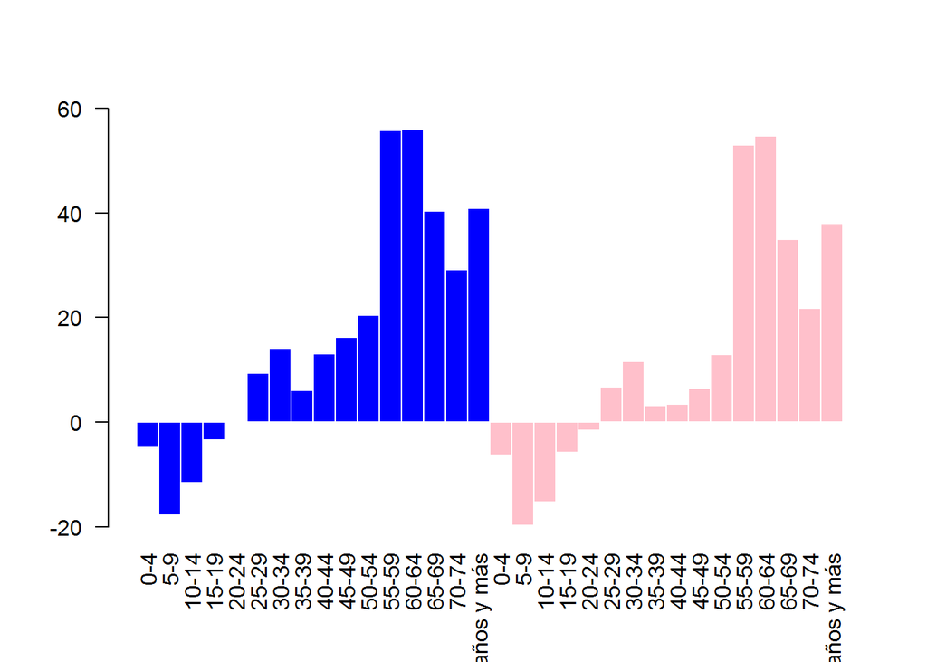

```r
# variacion 2011 con respecto a 2001
barplot(as.matrix(Variaciones[,5]),
    beside = TRUE, names.arg = Variaciones[,1],
    las=2, ylim=c(-20,60),
    col=evolucionSexos$colores,
    border="white")
```